# Predição de Votação de Deputados

Gabriel Morais Lúcio de Araújo

11 de dezembro de 2017

```r
## 75% of the sample size
smp_size <- floor(0.75 * nrow(eleicoes2014))

## set the seed to make your partition reproductible
set.seed(123)
train_ind <- sample(seq_len(nrow(eleicoes2014)), size = smp_size)

train <- eleicoes2014[train_ind, ]
test <- eleicoes2014[-train_ind, ]

## Kaggle
train.kaggle <- trainK
test.kaggle <- testK
```

### 1. Usando todas as variáveis disponíveis, tune (usando validação cruzada): (i) um modelo de regressão Ridge, (ii) um modelo de regressão Lasso e (iii) um modelo KNN. Para os modelos de regressão linear, o parâmetro a ser tunado é o lambda (penalização dos coeficientes) e o KNN o número de vizinhos. (9 pts.)

1 - Method = Ridge

```r
fitControl <- trainControl(method = "repeatedcv",
                           number = 5,
                           repeats = 5)

preProcValues <- c("center", "scale", "nzv")

model.ridge <- train(votos ~ .,
               data = train.kaggle,
               trControl = fitControl,
               method = "ridge",
               preProcess = preProcValues,
               tuneLength = 15)
model.ridge
```

```
## Ridge Regression
##
## 4152 samples
##   22 predictor
##
## Pre-processing: centered (33), scaled (33), remove (192)
## Resampling: Cross-Validated (5 fold, repeated 5 times)
## Summary of sample sizes: 3323, 3320, 3323, 3321, 3321, 3322, ...
## Resampling results across tuning parameters:
##
##   lambda        RMSE      Rsquared   MAE
##   0.0000000000  33700.40  0.4588461  12229.73
##   0.0001000000  33535.93  0.4627805  12183.33
##   0.0001701254  33528.74  0.4629775  12181.06
##   0.0002894266  33519.10  0.4632382  12178.59
##   0.0004923883  33505.52  0.4635975  12175.49
##   0.0008376776  33486.84  0.4640766  12171.41
##   0.0014251027  33462.58  0.4646678  12166.16
##   0.0024244620  33432.83  0.4653407  12161.18
##   0.0041246264  33397.04  0.4660909  12155.46
##   0.0070170383  33353.35  0.4669885  12150.61
##   0.0119377664  33301.10  0.4681392  12150.42
##   0.0203091762  33246.35  0.4695639  12154.02
##   0.0345510729  33205.54  0.4711356  12165.43
##   0.0587801607  33204.05  0.4727148  12195.54
##   0.1000000000  33278.90  0.4743810  12263.06
##
## RMSE was used to select the optimal model using the smallest value.
## The final value used for the model was lambda = 0.05878016.
```

2- Method = Lasso

```r
model.lasso <- train(votos ~ .,
                     data = train.kaggle,
                     trControl = fitControl,
                     method = "lasso",
                     preProcess = preProcValues,
                     tuneLength = 15)
model.lasso
```

```
## The lasso
##
## 4152 samples
##   22 predictor
##
## Pre-processing: centered (33), scaled (33), remove (192)
## Resampling: Cross-Validated (5 fold, repeated 5 times)
## Summary of sample sizes: 3323, 3321, 3321, 3322, 3321, 3322, ...
## Resampling results across tuning parameters:
##
##   fraction   RMSE      Rsquared   MAE
##   0.1000000  33784.07  0.4597327  13858.78
##   0.1571429  33150.65  0.4685989  12499.66
##   0.2142857  33053.54  0.4711628  12205.28
##   0.2714286  33087.32  0.4727438  12154.15
##   0.3285714  33122.98  0.4736717  12148.64
##   0.3857143  33180.27  0.4733676  12157.65
##   0.4428571  33209.98  0.4730252  12178.41
##   0.5000000  33219.25  0.4728829  12194.67
##   0.5571429  33233.91  0.4725368  12204.84
##   0.6142857  33258.72  0.4719112  12214.16
##   0.6714286  33282.73  0.4713655  12222.29
##   0.7285714  33294.80  0.4710688  12225.76
##   0.7857143  33302.00  0.4708499  12228.20
##   0.8428571  33309.11  0.4706240  12230.58
##   0.9000000  33317.17  0.4703703  12233.08
##
## RMSE was used to select the optimal model using the smallest value.
## The final value used for the model was fraction = 0.2142857.
```

3 - Method = KNN

```r
model.knn <- train(votos ~ .,
                     data = train.kaggle,
                     trControl = fitControl,
                     method = "knn",
                     preProcess = preProcValues,
                     tuneLength = 15)
model.knn
```

```
## k-Nearest Neighbors
##
## 4152 samples
##   22 predictor
##
## Pre-processing: centered (33), scaled (33), remove (192)
## Resampling: Cross-Validated (5 fold, repeated 5 times)
## Summary of sample sizes: 3323, 3320, 3321, 3321, 3323, 3322, ...
## Resampling results across tuning parameters:
##
##   k   RMSE      Rsquared   MAE
##    5  34591.97  0.4277048  11404.81
##    7  33589.41  0.4520710  11158.74
##    9  33096.53  0.4665037  11031.90
##   11  32785.13  0.4767120  10967.44
##   13  32550.22  0.4845652  10946.35
##   15  32387.49  0.4909558  10911.52
##   17  32356.63  0.4932848  10934.53
##   19  32271.47  0.4975312  10937.90
##   21  32239.97  0.4996848  10933.76
##   23  32216.62  0.5016276  10945.62
##   25  32221.56  0.5026165  10958.32
##   27  32262.21  0.5023406  10986.54
##   29  32239.74  0.5046806  10987.17
##   31  32259.56  0.5052431  11003.50
##   33  32318.88  0.5042458  11025.18
##
## RMSE was used to select the optimal model using the smallest value.
## The final value used for the model was k = 23.
```

### 3. Quais as variáveis mais importantes segundo o modelo de regressão Ridge e Lasso? Variáveis foram descartadas pelo Lasso? Quais? (9 pts.)

1 - Modelo Ridge

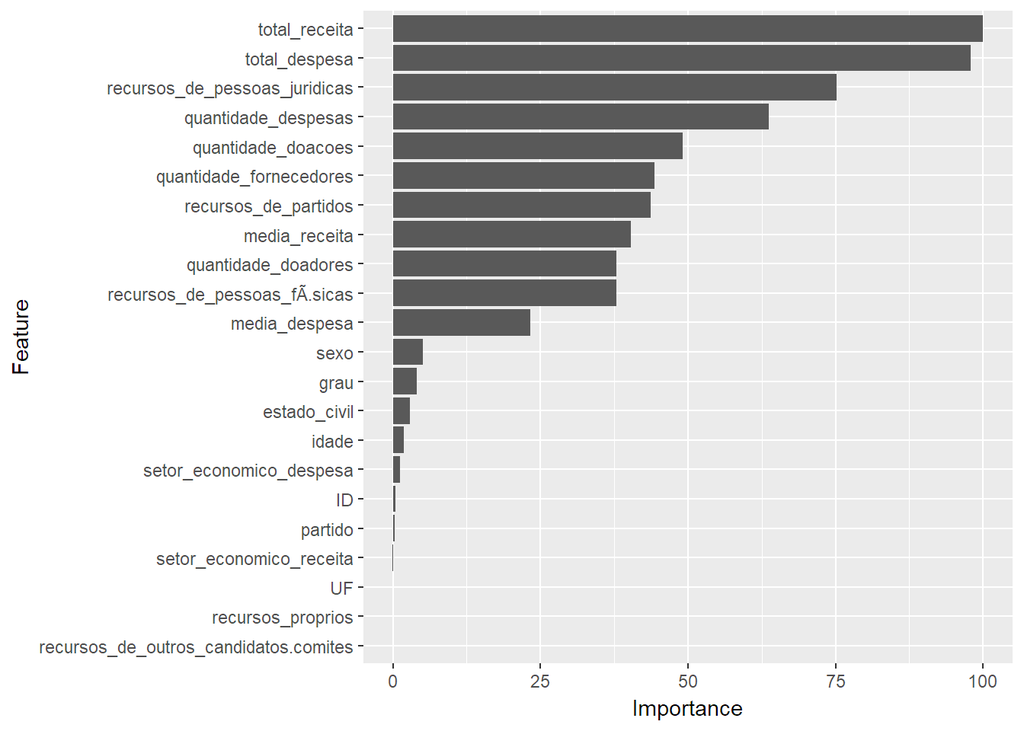

```r
ggplot(varImp(model.ridge))
```

2 - Modelo Lasso

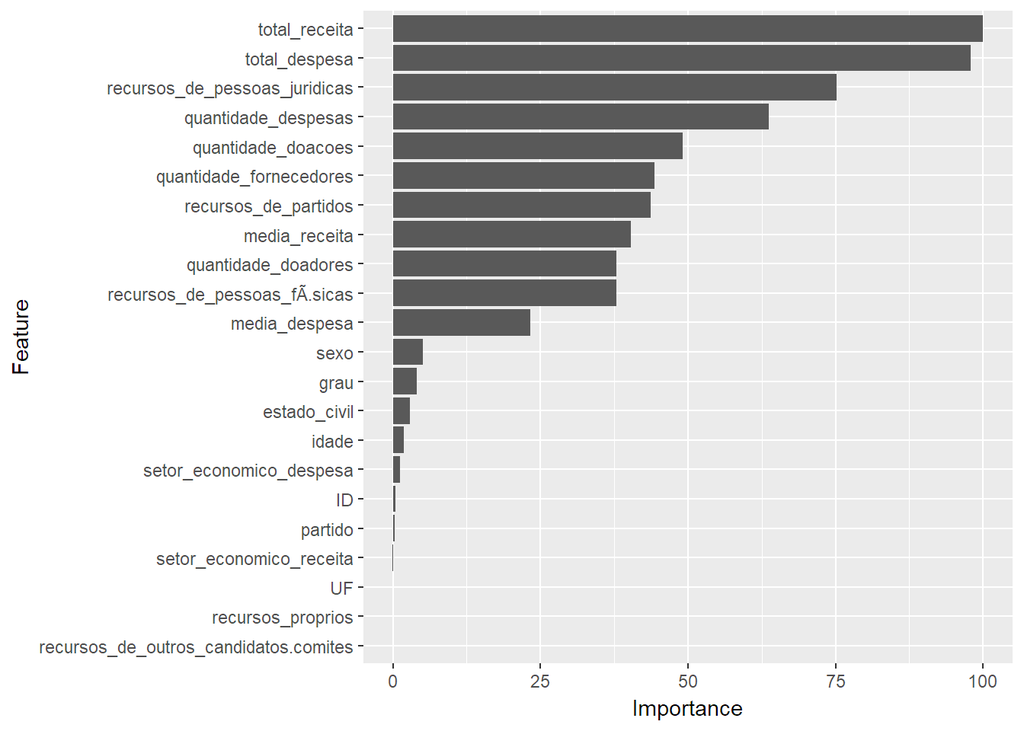

```r
ggplot(varImp(model.lasso))
```

As váriaveis mais importantes foram: total_receita, total_despesa, recursos_de_pessoas_juridicas, quantidade_despesas, quantidade_doacoes, quantidade_fornecedores, recursos_de_partidos e media_receita. As váriaveis menos importantes foram: setor_economico_receita, setor_economico_despesa, -ID, -UF, -partido, recursos_proprios e recursos_de_outros_cadidatos.comites. As váriaveis menos importantes serão descartadas no re-treino do modelo KNN, que obteve melhor RSME.

### 4. Re-treine o melhor modelo (usando os melhores valores de parâmetros encontrados em todos os dados, sem usar validação cruzada). (9 pts.)

```r
train.kaggle <- train.kaggle %>% select (-setor_economico_receita, -ID, -partido, -UF, -recursos_proprios, -recursos_de_outros_candidatos.comites, -setor_economico_despesa)

test.kaggle <- test.kaggle %>% select (-setor_economico_receita, -ID, -partido, -UF, -recursos_proprios, -recursos_de_outros_candidatos.comites, -setor_economico_despesa)

grid <- expand.grid(k = model.knn$bestTune)
tr <- trainControl(method = "optimism_boot")
model.knn <- train(votos ~ .,
               data = train.kaggle,
               method = "knn",
               tuneGrid = grid,
               trControl = tr,
               preProcess = preProcValues)
model.knn
```

```
## k-Nearest Neighbors
##
## 4152 samples
##   15 predictor
##
## Pre-processing: centered (18), scaled (18), remove (5)
## Resampling: Bootstrapped (25 reps)
## Summary of sample sizes: 4152, 4152, 4152, 4152, 4152, 4152, ...
## Resampling results:
##
##   RMSE      Rsquared   MAE
##   35504.01  0.4201188  10197.35
##
## Tuning parameter 'k' was held constant at a value of 23
```

### 5. Use esse último modelo treinado para prever os dados de teste que disponibilizaremos por meio da plataforma Kaggle: (a ser disponibilizado) (9 pts.)

```r
pred <- predict(model.knn, test.kaggle)
```

```r
submission.csv <- test.kaggle$ID
submission.csv$votos <- pred
submission.csv$votos[submission.csv$votos < 0] <- 0
write.csv(submission.csv, "sample_submission.csv", row.names=FALSE)
```